# Zambia Intermarriage Analysis

Author

Branden Bohrnsen

```r
library(pacman)
p_load(
    tidyverse, ggpubr, knitr, reshape2
)
```

Load data from cleaning script.

```r
individuals <- read.csv("exports/individuals.csv")

ethnic_proportions <- read.csv("exports/ethnic_proportions.csv")
ethnic_block_proportions <- read.csv("exports/ethnic_block_proportions.csv")

const_hhi <- read.csv("exports/const_hhi.csv") %>%
    select(-perfect) %>%
    mutate(fractionalization = 1 - hhi)
```

```r
plot_intermarriage <- function(data, title, group_var = NULL, exclude_decade = TRUE) {
    names(data) <- gsub("National_", "", names(data))
    names(data) <- gsub("Province_", "", names(data))
    names(data) <- gsub("Const_", "", names(data))

    if (exclude_decade) {
        data <- data %>% filter(!DecadeMarried %in% c("1921-1930", "1931-1940", "1941-1950"))
    }

    if (!is.null(group_var)) {
        data <- data %>% mutate(group = .data[[group_var]])
    } else {
        data <- data %>% mutate(group = 1)
    }

    data <- data %>%
        mutate(
            Observed_CI_lower = Observed_mean - 1.96 * Observed_SE,
            Observed_CI_upper = Observed_mean + 1.96 * Observed_SE,
            Adjusted_CI_lower = Adjusted_mean - 1.96 * Adjusted_SE,
            Adjusted_CI_upper = Adjusted_mean + 1.96 * Adjusted_SE,
            Expectation_CI_lower = Expectation_mean - 1.96 * Expectation_SE,
            Expectation_CI_upper = Expectation_mean + 1.96 * Expectation_SE
        )

    ggplot(data) +
    geom_line(aes(x = DecadeMarried, y = Observed_mean, group = group, color = "Observed")) +
    geom_ribbon(aes(x = DecadeMarried, ymin = Observed_CI_lower, ymax = Observed_CI_upper, group = group, fill = "Observed"), alpha = 0.1) +
    geom_line(aes(x = DecadeMarried, y = Adjusted_mean, group = group, color = "Controlling for Exposure")) +
    geom_ribbon(aes(x = DecadeMarried, ymin = Adjusted_CI_lower, ymax = Adjusted_CI_upper, group = group, fill = "Controlling for Exposure"), alpha = 0.1) +
    geom_line(aes(x = DecadeMarried, y = Expectation_mean, group = group, color = "Expected")) +
    geom_ribbon(aes(x = DecadeMarried, ymin = Expectation_CI_lower, ymax = Expectation_CI_upper, group = group, fill = "Expected"), alpha = 0.1) +
    scale_color_manual(values = c("Observed" = "red", "Controlling for Exposure" = "blue", "Expected" = "black")) +
    scale_fill_manual(values = c("Observed" = "red", "Controlling for Exposure" = "blue", "Expected" = "black"), guide = "none") +
    theme_pubclean() +
    theme(axis.text.x = element_text(angle = 45, vjust = 1, hjust = 1)) +
    labs(title = title, color = "", fill = "", x = "Decade Married", y = "Value")

}

plot_intermarriage_difference <- function(data, title, group_var = NULL, exclude_decade = TRUE) {
    names(data) <- gsub("National_", "", names(data))
    names(data) <- gsub("Province_", "", names(data))
    names(data) <- gsub("Const_", "", names(data))

    if (exclude_decade) {
        data <- data %>% filter(!DecadeMarried %in% c("1921-1930", "1931-1940", "1941-1950"))
    }

    if (!is.null(group_var)) {
        data <- data %>% mutate(group = .data[[group_var]])
    } else {
        data <- data %>% mutate(group = 1)
    }

    data <- data %>%
        mutate(
            Difference = Adjusted_mean - Observed_mean,
            Difference_SE = sqrt(Adjusted_SE^2 + Observed_SE^2),
            CI_lower = Difference - 1.96 * Difference_SE,
            CI_upper = Difference + 1.96 * Difference_SE
        )

    ggplot(data) +
        geom_line(aes(x = DecadeMarried, y = Difference, group = group, color = as.factor(group))) +
        geom_ribbon(aes(x = DecadeMarried, ymin = CI_lower, ymax = CI_upper, group = group, fill = as.factor(group)), alpha = 0.1) +
        scale_color_discrete(name = group_var) +
        scale_fill_discrete(name = group_var) +
        theme_pubclean() +
        theme(axis.text.x = element_text(angle = 45, vjust = 1, hjust = 1)) +
        labs(title = title, color = "", x = "Decade Married", y = "Difference (Controlling for Exposure - Observed)")
}
```

Weighted standard errors that account for effective degrees of freedom:

```r
weighted_se_mean <- function(x, w, na.rm = TRUE) {
    if (na.rm) {
        i <- !is.na(x)
        w <- w[i]
        x <- x[i]
    }
    n_eff <- (sum(w))^2 / sum(w^2)
    correction <- n_eff / (n_eff - 1)
    numerator <- sum(w * (x - weighted.mean(x, w))^2)
    denominator <- sum(w)
    sqrt((correction * (numerator / denominator)) / n_eff)
}
```

Process constituency-level data, storing the observed, expected, and adjusted values. Also finds the population with the number of rows. Process is repeated for ethnic blocks. NAs are removed because some denominators are zero (aka no exposure due to small samples) – all data has been scanned for missingness.

```r
process_constituency_ethnic <- function(data) {
    const_intermarriage_ethnic <- data %>%
        select(Const, District, Province, Ethnicity, EthnicOutmarriage) %>%
        left_join(y = ethnic_proportions, by = join_by(Const, Ethnicity)) %>%
        group_by(Const, District, Province, Ethnicity, Proportion) %>%
        reframe(Observed = mean(EthnicOutmarriage), n = n()) %>%
        mutate(Expectation = 1 - Proportion) %>%
        mutate(Adjusted = Observed / Expectation) %>%
        ungroup()

    const_ethnic <- const_intermarriage_ethnic %>%
        group_by(Const, District, Province) %>%
        mutate(Const_Population = sum(n)) %>%
        ungroup()

    const_ethnic <- const_ethnic %>%
        group_by(Const, District, Province) %>%
        summarise(
            Const_Population = sum(n),
            Const_Adjusted_mean = weighted.mean(Adjusted, Proportion, na.rm = TRUE),
            Const_Observed_mean = weighted.mean(Observed, Proportion, na.rm = TRUE),
            Const_Expectation_mean = weighted.mean(Expectation, Proportion, na.rm = TRUE),
            Adjusted_SE = weighted_se_mean(Adjusted, Proportion),
            Observed_SE = weighted_se_mean(Observed, Proportion),
            Expectation_SE = weighted_se_mean(Expectation, Proportion)
        ) %>%
        ungroup() %>%
        left_join(y = const_hhi, join_by(Const))

    #print("Processed constituencies")
    return(const_ethnic)
}

process_constituency_block <- function(data) {
    const_intermarriage_block <- data %>%
        select(Const, District, Province, EthnicBlock, BlockOutmarriage) %>%
        left_join(y = ethnic_block_proportions, by = join_by(Const, EthnicBlock)) %>%
        group_by(Const, District, Province, EthnicBlock, Proportion) %>%
        reframe(Observed = mean(BlockOutmarriage), n = n()) %>%
        mutate(Expectation = 1 - Proportion) %>%
        mutate(Adjusted = Observed / Expectation) %>%
        ungroup()

    const_block <- const_intermarriage_block %>%
        group_by(Const, District, Province) %>%
        mutate(Const_Population = sum(n)) %>%
        ungroup()

    const_block <- const_block %>%
        group_by(Const, District, Province) %>%
        summarise(
            Const_Population = sum(n),
            Const_Adjusted_mean = weighted.mean(Adjusted, Proportion, na.rm = TRUE),
            Const_Observed_mean = weighted.mean(Observed, Proportion, na.rm = TRUE),
            Const_Expectation_mean = weighted.mean(Expectation, Proportion, na.rm = TRUE),
            Adjusted_SE = weighted_se_mean(Adjusted, Proportion),
            Observed_SE = weighted_se_mean(Observed, Proportion),
            Expectation_SE = weighted_se_mean(Expectation, Proportion)
        ) %>%
        ungroup() %>%
        left_join(y = const_hhi, join_by(Const))

    return(const_block)
    #"Processed constituencies, ethnic block")
}
```

Aggregate from constituencies to provinces. We weigh both the means and the standard errors by population. Process is repeated for the countrywide estimates.

```r
aggregate_to_district <- function(const_data) {
    district_data <- const_data %>%
    select(-Const) %>%
    group_by(District) %>%
    summarise(
        District_Population = sum(Const_Population),
        District_Adjusted_mean = weighted.mean(Const_Adjusted_mean, Const_Population, na.rm = TRUE),
        District_Observed_mean = weighted.mean(Const_Observed_mean, Const_Population, na.rm = TRUE),
        District_Expectation_mean = weighted.mean(Const_Expectation_mean, Const_Population, na.rm = TRUE),
        District_Adjusted_SE = weighted_se_mean(Const_Adjusted_mean, Const_Population),
        District_Observed_SE = weighted_se_mean(Const_Observed_mean, Const_Population),
        District_Expectation_SE = weighted_se_mean(Const_Expectation_mean, Const_Population),
        District_HHI = weighted.mean(hhi, Const_Population)
    ) %>%
    ungroup()
    #print("Processed districts")
    return(district_data)
}

aggregate_to_province <- function(const_data) {
    province_data <- const_data %>%
    select(-Const, -District) %>%
    group_by(Province) %>%
    summarise(
        Province_Population = sum(Const_Population),
        Province_Adjusted_mean = weighted.mean(Const_Adjusted_mean, Const_Population, na.rm = TRUE),
        Province_Observed_mean = weighted.mean(Const_Observed_mean, Const_Population, na.rm = TRUE),
        Province_Expectation_mean = weighted.mean(Const_Expectation_mean, Const_Population, na.rm = TRUE),
        Province_Adjusted_SE = weighted_se_mean(Const_Adjusted_mean, Const_Population),
        Province_Observed_SE = weighted_se_mean(Const_Observed_mean, Const_Population),
        Province_Expectation_SE = weighted_se_mean(Const_Expectation_mean, Const_Population),
        Province_HHI = weighted.mean(hhi, Const_Population)
    ) %>%
    ungroup()
    #print("Processed provinces")
    return(province_data)
}

aggregate_to_national <- function(const_data) {
    national_data <- const_data %>%
    select(-Const, -District, -Province) %>%
    summarise(
        National_Population = sum(Const_Population),
        National_Adjusted_mean = weighted.mean(Const_Adjusted_mean, Const_Population, na.rm = TRUE),
        National_Observed_mean = weighted.mean(Const_Observed_mean, Const_Population, na.rm = TRUE),
        National_Expectation_mean = weighted.mean(Const_Expectation_mean, Const_Population, na.rm = TRUE),
        National_Adjusted_SE = weighted_se_mean(Const_Adjusted_mean, Const_Population),
        National_Observed_SE = weighted_se_mean(Const_Observed_mean, Const_Population),
        National_Expectation_SE = weighted_se_mean(Const_Expectation_mean, Const_Population),
        National_HHI = weighted.mean(hhi, Const_Population)
    ) %>%
    ungroup()

    #print("Processed national")
    return(national_data)
}
```

```r
process_constituency_ethnic_by_decade <- function(data) {
    const_intermarriage_ethnic <- data %>%
        select(Const, District, Province, Ethnicity, EthnicOutmarriage, DecadeMarried) %>%
        left_join(y = ethnic_proportions, by = join_by(Const, Ethnicity)) %>%
        group_by(Const, District, Province, Ethnicity, Proportion, DecadeMarried) %>%
        reframe(Observed = mean(EthnicOutmarriage), n = n()) %>%
        mutate(Expectation = 1 - Proportion) %>%
        mutate(Adjusted = Observed / Expectation) %>%
        ungroup()

    const_ethnic <- const_intermarriage_ethnic %>%
        group_by(Const, District, Province, DecadeMarried) %>%
        mutate(Const_Population = sum(n)) %>%
        ungroup()

    const_ethnic <- const_ethnic %>%
        group_by(Const, District, Province, DecadeMarried) %>%
        summarise(
            Const_Population = sum(n),
            Const_Adjusted_mean = weighted.mean(Adjusted, Proportion, na.rm = TRUE),
            Const_Observed_mean = weighted.mean(Observed, Proportion, na.rm = TRUE),
            Const_Expectation_mean = weighted.mean(Expectation, Proportion, na.rm = TRUE),
            Adjusted_SE = weighted_se_mean(Adjusted, Proportion),
            Observed_SE = weighted_se_mean(Observed, Proportion),
            Expectation_SE = weighted_se_mean(Expectation, Proportion)
        ) %>%
        ungroup() %>%
        left_join(y = const_hhi, join_by(Const))

    #print("Processed constituency by decade")
    return(const_ethnic)
}

process_constituency_block_by_decade <- function(data) {
    const_intermarriage_block <- data %>%
        select(Const, District, Province, EthnicBlock, BlockOutmarriage, DecadeMarried) %>%
        left_join(y = ethnic_block_proportions, by = join_by(Const, EthnicBlock)) %>%
        group_by(Const, District, Province, EthnicBlock, Proportion, DecadeMarried) %>%
        reframe(Observed = mean(BlockOutmarriage), n = n()) %>%
        mutate(Expectation = 1 - Proportion) %>%
        mutate(Adjusted = Observed / Expectation) %>%
        ungroup()

    const_block <- const_intermarriage_block %>%
        group_by(Const, District, Province, DecadeMarried) %>%
        mutate(Const_Population = sum(n)) %>%
        ungroup()

    const_block <- const_block %>%
        group_by(Const, District, Province, DecadeMarried) %>%
        summarise(
            Const_Population = sum(n),
            Const_Adjusted_mean = weighted.mean(Adjusted, Proportion, na.rm = TRUE),
            Const_Observed_mean = weighted.mean(Observed, Proportion, na.rm = TRUE),
            Const_Expectation_mean = weighted.mean(Expectation, Proportion, na.rm = TRUE),
            Adjusted_SE = weighted_se_mean(Adjusted, Proportion),
            Observed_SE = weighted_se_mean(Observed, Proportion),
            Expectation_SE = weighted_se_mean(Expectation, Proportion)
        ) %>%
        ungroup() %>%
        left_join(y = const_hhi, join_by(Const))

    #print("Processed constituencies by decade, ethnic block")
    return(const_block)
}
```

```r
aggregate_to_district_by_decade <- function(const_data) {
    district_data <- const_data %>%
    select(-Const) %>%
    group_by(District, DecadeMarried) %>%
    summarise(
        District_Population = sum(Const_Population),
        District_Adjusted_mean = weighted.mean(Const_Adjusted_mean, Const_Population, na.rm = TRUE),
        District_Observed_mean = weighted.mean(Const_Observed_mean, Const_Population, na.rm = TRUE),
        District_Expectation_mean = weighted.mean(Const_Expectation_mean, Const_Population, na.rm = TRUE),
        District_Adjusted_SE = weighted_se_mean(Const_Adjusted_mean, Const_Population),
        District_Observed_SE = weighted_se_mean(Const_Observed_mean, Const_Population),
        District_Expectation_SE = weighted_se_mean(Const_Expectation_mean, Const_Population),
        District_HHI = weighted.mean(hhi, Const_Population)
    ) %>%
    ungroup()

    #print("Processed districts by decade")
    return(district_data)
}

aggregate_to_province_by_decade <- function(const_data) {
    province_data <- const_data %>%
    select(-Const, -District) %>%
    group_by(Province, DecadeMarried) %>%
    summarise(
        Province_Population = sum(Const_Population),
        Province_Adjusted_mean = weighted.mean(Const_Adjusted_mean, Const_Population, na.rm = TRUE),
        Province_Observed_mean = weighted.mean(Const_Observed_mean, Const_Population, na.rm = TRUE),
        Province_Expectation_mean = weighted.mean(Const_Expectation_mean, Const_Population, na.rm = TRUE),
        Province_Adjusted_SE = weighted_se_mean(Const_Adjusted_mean, Const_Population),
        Province_Observed_SE = weighted_se_mean(Const_Observed_mean, Const_Population),
        Province_Expectation_SE = weighted_se_mean(Const_Expectation_mean, Const_Population),
        Province_HHI = weighted.mean(hhi, Const_Population)
    ) %>%
    ungroup()

    #print("Processed provinces by decade")
    return(province_data)
}

aggregate_to_national_by_decade <- function(const_data) {
    national_data <- const_data %>%
    select(-Const, -District, -Province) %>%
    group_by(DecadeMarried) %>%
    summarise(
        National_Population = sum(Const_Population),
        National_Adjusted_mean = weighted.mean(Const_Adjusted_mean, Const_Population, na.rm = TRUE),
        National_Observed_mean = weighted.mean(Const_Observed_mean, Const_Population, na.rm = TRUE),
        National_Expectation_mean = weighted.mean(Const_Expectation_mean, Const_Population, na.rm = TRUE),
        National_Adjusted_SE = weighted_se_mean(Const_Adjusted_mean, Const_Population),
        National_Observed_SE = weighted_se_mean(Const_Observed_mean, Const_Population),
        National_Expectation_SE = weighted_se_mean(Const_Expectation_mean, Const_Population),
        National_HHI = weighted.mean(hhi, Const_Population)
    ) %>%
    ungroup()

    #print("Processed national by decade")
    return(national_data)
}
```

Connect functions together.

```r
calculate_results <- function(data) {
    const_ethnic <- process_constituency_ethnic(data)
    const_block <- process_constituency_block(data)

    provincial_ethnic <- aggregate_to_province(const_ethnic)
    provincial_block <- aggregate_to_province(const_block)

    national_ethnic <- aggregate_to_national(const_ethnic)
    national_block <- aggregate_to_national(const_block)

    const_ethnic_by_decade <- process_constituency_ethnic_by_decade(data)
    const_block_by_decade <- process_constituency_block_by_decade(data)

    national_ethnic_by_decade <- aggregate_to_national_by_decade(const_ethnic_by_decade)
    national_block_by_decade <- aggregate_to_national_by_decade(const_block_by_decade)

    list(
        const_ethnic = const_ethnic,
        const_block = const_block,
        national_ethnic = national_ethnic,
        national_block = national_block,
        province_ethnic = provincial_ethnic,
        province_block = provincial_block,
        national_ethnic_by_decade = national_ethnic_by_decade,
        national_block_by_decade = national_block_by_decade
    )
}
```

Run iterations of the function for every sample we are interested in.

```r
run_filters <- function(data) {
    filters <- list(
        "full" = data,
        "urban" = data %>% filter(Urbanization >= 0.5),
        "top_quartile" = data %>% filter(Urbanization >= quantile(Urbanization, 0.75)),
        "rural" = data %>% filter(Urbanization < 0.5),
        "bottom_quartile" = data %>% filter(Urbanization <= quantile(Urbanization, 0.25))
    )

    results_dfs <- list()

    for (filter_name in names(filters)) {
        filtered_data <- filters[[filter_name]]
        result <- calculate_results(filtered_data)

        results_dfs[[paste0(filter_name, "_const_ethnic")]] <- result$const_ethnic
        results_dfs[[paste0(filter_name, "_const_block")]] <- result$const_block
        results_dfs[[paste0(filter_name, "_national_ethnic")]] <- result$national_ethnic
        results_dfs[[paste0(filter_name, "_national_block")]] <- result$national_block
        results_dfs[[paste0(filter_name, "_province_ethnic")]] <- result$province_ethnic
        results_dfs[[paste0(filter_name, "_province_block")]] <- result$province_block
        results_dfs[[paste0(filter_name, "_national_ethnic_by_decade")]] <- result$national_ethnic_by_decade
        results_dfs[[paste0(filter_name, "_national_block_by_decade")]] <- result$national_block_by_decade
    }

    results_dfs
}

all_results_dfs <- run_filters(individuals)
```

Plot selected outcomes.

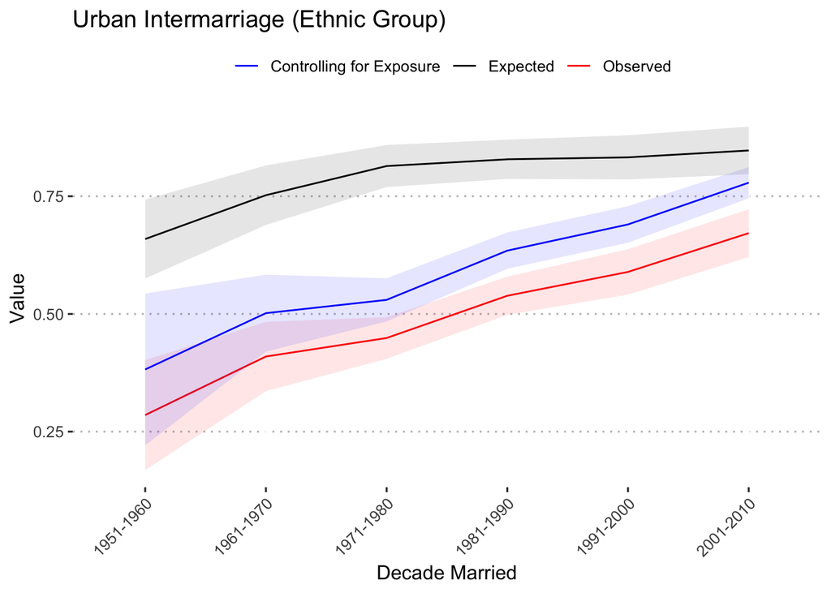

```r
plot_intermarriage(
    all_results_dfs$urban_national_ethnic_by_decade,
    title = "Urban Intermarriage (Ethnic Group)",
    exclude_decade = TRUE
)
```

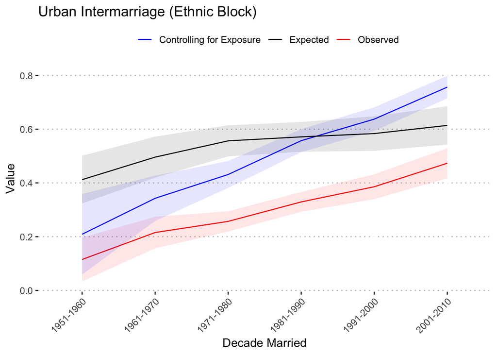

```r
plot_intermarriage(
    all_results_dfs$urban_national_block_by_decade,
    title = "Urban Intermarriage (Ethnic Block)",
    exclude_decade = TRUE
)
```

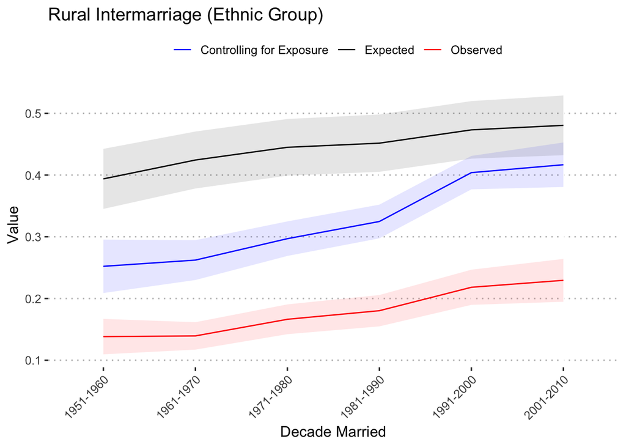

```r
plot_intermarriage(
    all_results_dfs$rural_national_ethnic_by_decade,
    title = "Rural Intermarriage (Ethnic Group)",
    exclude_decade = TRUE
)
```

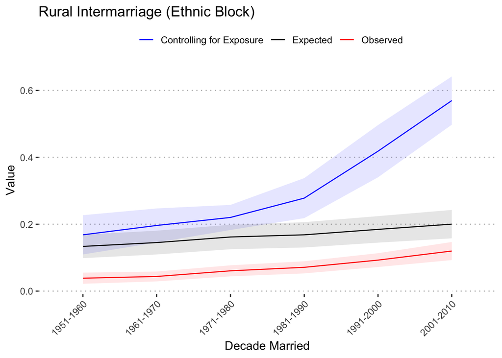

```r
plot_intermarriage(
    all_results_dfs$rural_national_block_by_decade,
    title = "Rural Intermarriage (Ethnic Block)",
    exclude_decade = TRUE
)
```

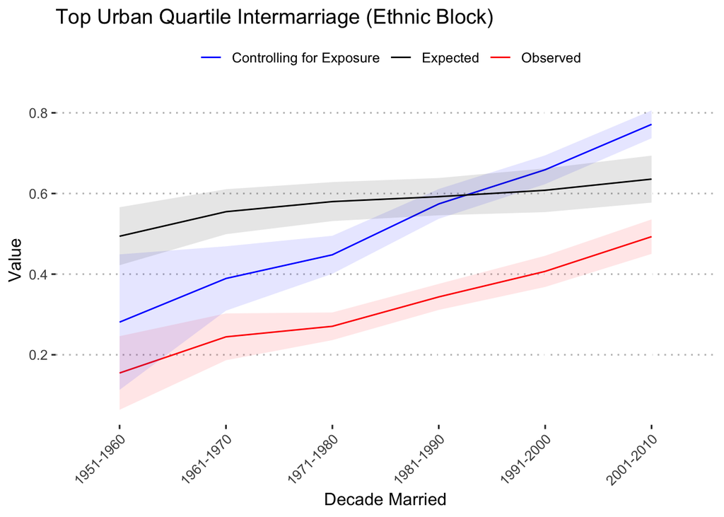

```r
plot_intermarriage(
    all_results_dfs$top_quartile_national_block_by_decade,
    title = "Top Urban Quartile Intermarriage (Ethnic Block)",
    exclude_decade = TRUE
)
```

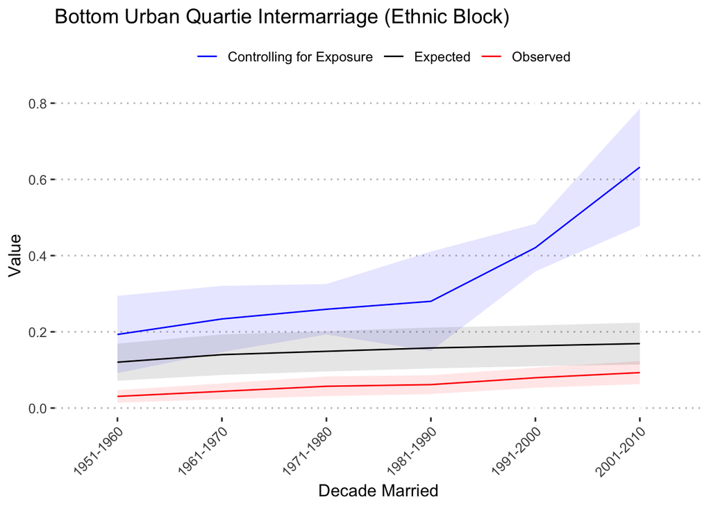

```r
plot_intermarriage(
    all_results_dfs$bottom_quartile_national_block_by_decade,
    title = "Bottom Urban Quartie Intermarriage (Ethnic Block)",
    exclude_decade = TRUE
)
```

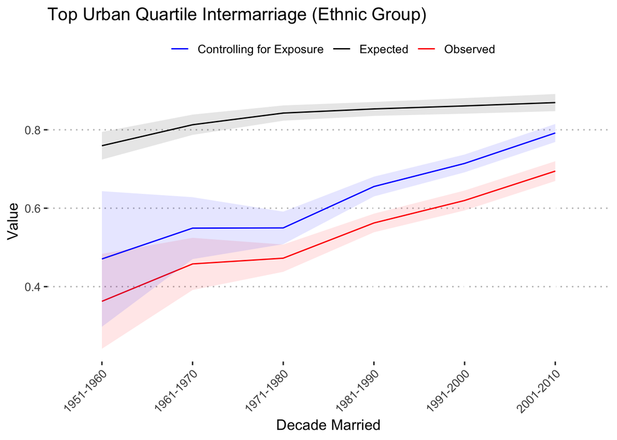

```r
plot_intermarriage(
    all_results_dfs$top_quartile_national_ethnic_by_decade,
    title = "Top Urban Quartile Intermarriage (Ethnic Group)",
    exclude_decade = TRUE
)
```

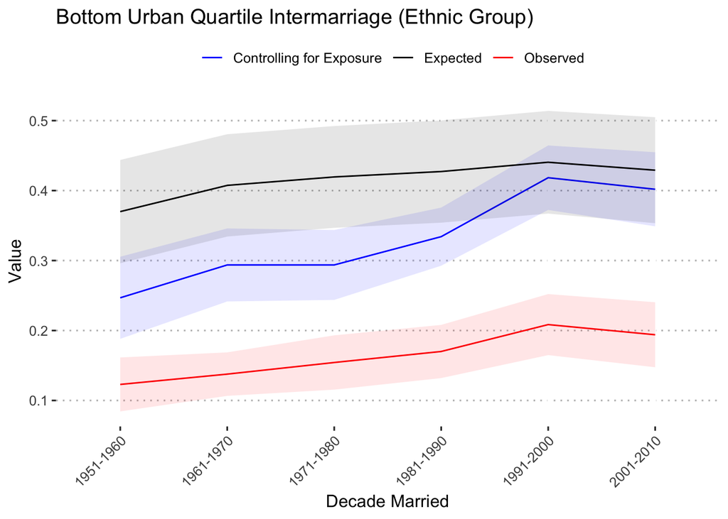

```r
plot_intermarriage(
    all_results_dfs$bottom_quartile_national_ethnic_by_decade,
    title = "Bottom Urban Quartile Intermarriage (Ethnic Group)",
    exclude_decade = TRUE
)
```

Plots by urbanization group.

```r
process_constituency_ethnic_by_urbanization <- function(data) {
    const_intermarriage_ethnic <- data %>%
        mutate(Urbanization_Group = cut(Urbanization, breaks = seq(0, 1, by = 0.1), labels = seq(0.1, 1, by = 0.1), include.lowest = TRUE)) %>%
        select(Const, District, Province, Ethnicity, EthnicOutmarriage, Urbanization_Group) %>%
        left_join(y = ethnic_proportions, by = join_by(Const, Ethnicity)) %>%
        group_by(Const, District, Province, Ethnicity, Proportion, Urbanization_Group) %>%
        reframe(Observed = mean(EthnicOutmarriage), n = n()) %>%
        mutate(Expectation = 1 - Proportion) %>%
        mutate(Adjusted = Observed / Expectation) %>%
        ungroup()

    const_ethnic <- const_intermarriage_ethnic %>%
        group_by(Const, District, Province, Urbanization_Group) %>%
        summarise(
            Const_Population = sum(n),
            Const_Adjusted_mean = weighted.mean(Adjusted, Proportion, na.rm = TRUE),
            Const_Observed_mean = weighted.mean(Observed, Proportion, na.rm = TRUE),
            Const_Expectation_mean = weighted.mean(Expectation, Proportion, na.rm = TRUE),
            Adjusted_SE = weighted_se_mean(Adjusted, Proportion),
            Observed_SE = weighted_se_mean(Observed, Proportion),
            Expectation_SE = weighted_se_mean(Expectation, Proportion)
        ) %>%
        ungroup()

    urbanization_ethnic <- const_ethnic %>%
        group_by(Urbanization_Group) %>%
        summarise(
            Urbanization_Population = sum(Const_Population),
            Urbanization_Adjusted_mean = weighted.mean(Const_Adjusted_mean, Const_Population, na.rm = TRUE),
            Urbanization_Observed_mean = weighted.mean(Const_Observed_mean, Const_Population, na.rm = TRUE),
            Urbanization_Expectation_mean = weighted.mean(Const_Expectation_mean, Const_Population, na.rm = TRUE),
            Adjusted_SE = weighted_se_mean(Const_Adjusted_mean, Const_Population),
            Observed_SE = weighted_se_mean(Const_Observed_mean, Const_Population),
            Expectation_SE = weighted_se_mean(Const_Expectation_mean, Const_Population)
        ) %>%
        mutate(
            Adjusted_CI_lower = Urbanization_Adjusted_mean - 1.96 * Adjusted_SE,
            Adjusted_CI_upper = Urbanization_Adjusted_mean + 1.96 * Adjusted_SE,
            Observed_CI_lower = Urbanization_Observed_mean - 1.96 * Observed_SE,
            Observed_CI_upper = Urbanization_Observed_mean + 1.96 * Observed_SE,
            Expectation_CI_lower = Urbanization_Expectation_mean - 1.96 * Expectation_SE,
            Expectation_CI_upper = Urbanization_Expectation_mean + 1.96 * Expectation_SE
        ) %>%
        ungroup()

    return(urbanization_ethnic)
}

process_constituency_block_by_urbanization <- function(data) {
    const_intermarriage_block <- data %>%
        mutate(Urbanization_Group = cut(Urbanization, breaks = seq(0, 1, by = 0.1), labels = seq(0.1, 1, by = 0.1), include.lowest = TRUE)) %>%
        select(Const, District, Province, EthnicBlock, BlockOutmarriage, Urbanization_Group) %>%
        left_join(y = ethnic_block_proportions, by = join_by(Const, EthnicBlock)) %>%
        group_by(Const, District, Province, EthnicBlock, Proportion, Urbanization_Group) %>%
        reframe(Observed = mean(BlockOutmarriage), n = n()) %>%
        mutate(Expectation = 1 - Proportion) %>%
        mutate(Adjusted = Observed / Expectation) %>%
        ungroup()

    const_block <- const_intermarriage_block %>%
        group_by(Const, District, Province, Urbanization_Group) %>%
        summarise(
            Const_Population = sum(n),
            Const_Adjusted_mean = weighted.mean(Adjusted, Proportion, na.rm = TRUE),
            Const_Observed_mean = weighted.mean(Observed, Proportion, na.rm = TRUE),
            Const_Expectation_mean = weighted.mean(Expectation, Proportion, na.rm = TRUE),
            Adjusted_SE = weighted_se_mean(Adjusted, Proportion),
            Observed_SE = weighted_se_mean(Observed, Proportion),
            Expectation_SE = weighted_se_mean(Expectation, Proportion)
        ) %>%
        ungroup()

    urbanization_block <- const_block %>%
        group_by(Urbanization_Group) %>%
        summarise(
            Urbanization_Population = sum(Const_Population),
            Urbanization_Adjusted_mean = weighted.mean(Const_Adjusted_mean, Const_Population, na.rm = TRUE),
            Urbanization_Observed_mean = weighted.mean(Const_Observed_mean, Const_Population, na.rm = TRUE),
            Urbanization_Expectation_mean = weighted.mean(Const_Expectation_mean, Const_Population, na.rm = TRUE),
            Adjusted_SE = weighted_se_mean(Const_Adjusted_mean, Const_Population),
            Observed_SE = weighted_se_mean(Const_Observed_mean, Const_Population),
            Expectation_SE = weighted_se_mean(Const_Expectation_mean, Const_Population)
        ) %>%
        mutate(
            Adjusted_CI_lower = Urbanization_Adjusted_mean - 1.96 * Adjusted_SE,
            Adjusted_CI_upper = Urbanization_Adjusted_mean + 1.96 * Adjusted_SE,
            Observed_CI_lower = Urbanization_Observed_mean - 1.96 * Observed_SE,
            Observed_CI_upper = Urbanization_Observed_mean + 1.96 * Observed_SE,
            Expectation_CI_lower = Urbanization_Expectation_mean - 1.96 * Expectation_SE,
            Expectation_CI_upper = Urbanization_Expectation_mean + 1.96 * Expectation_SE
        ) %>%
        ungroup()

    return(urbanization_block)
}
```

```r
marriage_by_urbanization_ethnic <- individuals %>% process_constituency_ethnic_by_urbanization()
marriage_by_urbanization_block <- individuals %>% process_constituency_block_by_urbanization()
melted_ethnic <- melt(marriage_by_urbanization_ethnic,
                    id.vars = c("Urbanization_Group", "Urbanization_Population"),
                    measure.vars = c("Urbanization_Adjusted_mean", "Urbanization_Observed_mean"),
                    variable.name = "Rate_Type",
                    value.name = "Mean_Rate")

melted_se_ethnic <- melt(marriage_by_urbanization_ethnic,
                  id.vars = c("Urbanization_Group", "Urbanization_Population"),
                  measure.vars = c("Adjusted_SE", "Observed_SE"),
                  variable.name = "SE_Type",
                  value.name = "SE")

melted_ethnic$SE <- melted_se_ethnic$SE

melted_block <- melt(marriage_by_urbanization_block,
                    id.vars = c("Urbanization_Group", "Urbanization_Population"),
                    measure.vars = c("Urbanization_Adjusted_mean", "Urbanization_Observed_mean"),
                    variable.name = "Rate_Type",
                    value.name = "Mean_Rate")

melted_se_block <- melt(marriage_by_urbanization_block,
                  id.vars = c("Urbanization_Group", "Urbanization_Population"),
                  measure.vars = c("Adjusted_SE", "Observed_SE"),
                  variable.name = "SE_Type",
                  value.name = "SE")

melted_block$SE <- melted_se_block$SE
```

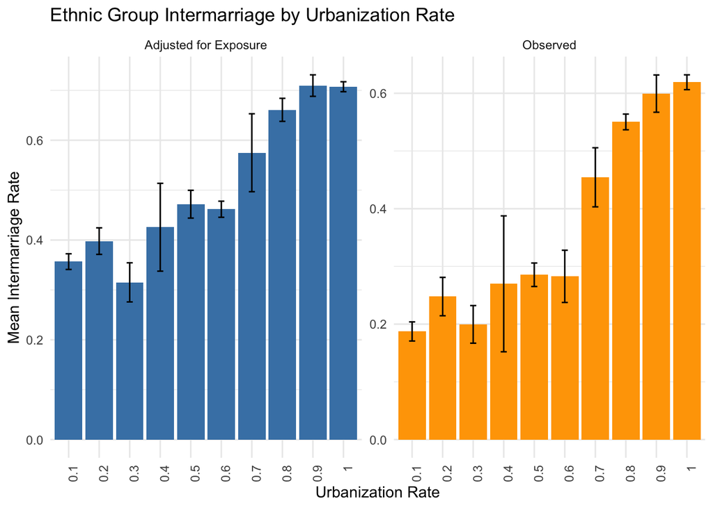

```r
ggplot(melted_ethnic, aes(x = Urbanization_Group, y = Mean_Rate, fill = Rate_Type)) +
    geom_bar(stat = "identity", position = "dodge") +
    geom_errorbar(aes(ymin = Mean_Rate - SE, ymax = Mean_Rate + SE),
                  position = position_dodge(width = 0.9), width = 0.2) +
    facet_wrap(~ Rate_Type, scales = "free_y", labeller = as_labeller(c(
        "Urbanization_Adjusted_mean" = "Adjusted for Exposure",
        "Urbanization_Observed_mean" = "Observed"
    ))) +
    labs(
        title = "Ethnic Group Intermarriage by Urbanization Rate",
        x = "Urbanization Rate",
        y = "Mean Intermarriage Rate"
    ) +
    scale_fill_manual(values = c("steelblue", "orange"), guide = "none") +
    theme_minimal() +
    theme(axis.text.x = element_text(angle = 90, hjust = 1))
```

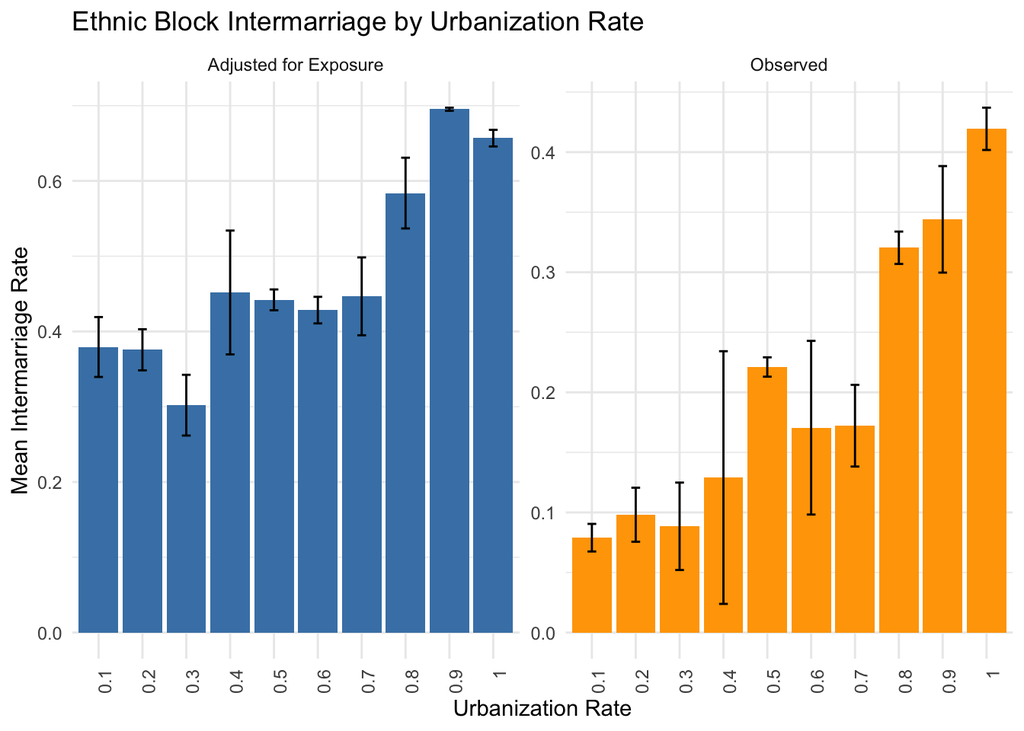

```r
ggplot(melted_block, aes(x = Urbanization_Group, y = Mean_Rate, fill = Rate_Type)) +
    geom_bar(stat = "identity", position = "dodge") +
    geom_errorbar(aes(ymin = Mean_Rate - SE, ymax = Mean_Rate + SE),
                  position = position_dodge(width = 0.9), width = 0.2) +
    facet_wrap(~ Rate_Type, scales = "free_y", labeller = as_labeller(c(
        "Urbanization_Adjusted_mean" = "Adjusted for Exposure",
        "Urbanization_Observed_mean" = "Observed"
    ))) +
    labs(
        title = "Ethnic Block Intermarriage by Urbanization Rate",
        x = "Urbanization Rate",
        y = "Mean Intermarriage Rate"
    ) +
    scale_fill_manual(values = c("steelblue", "orange"), guide = "none") +
    theme_minimal() +
    theme(axis.text.x = element_text(angle = 90, hjust = 1))
```

Building tables

```r
row_one_ethnic <- all_results_dfs$full_national_ethnic %>%
    mutate(Sample = "National", Grouping = "Ethnic Group") %>%
    select(
        Sample,
        Grouping,
        Population = National_Population,
        Adjusted = National_Adjusted_mean,
        Adjusted_SE = National_Adjusted_SE,
        Observed = National_Observed_mean,
        Observed_SE = National_Observed_SE
    )

row_one_block <- all_results_dfs$full_national_block %>%
    mutate(Sample = "National", Grouping = "Ethnic Block") %>%
    select(
        Sample,
        Grouping,
        Population = National_Population,
        Adjusted = National_Adjusted_mean,
        Adjusted_SE = National_Adjusted_SE,
        Observed = National_Observed_mean,
        Observed_SE = National_Observed_SE
    )

row_two_ethnic <- all_results_dfs$full_national_ethnic_by_decade %>%
    rename(Sample = DecadeMarried) %>%
    mutate(Grouping = "Ethnic Group") %>%
    select(
        Sample,
        Grouping,
        Population = National_Population,
        Adjusted = National_Adjusted_mean,
        Adjusted_SE = National_Adjusted_SE,
        Observed = National_Observed_mean,
        Observed_SE = National_Observed_SE
    )

row_two_block <- all_results_dfs$full_national_block_by_decade %>%
    rename(Sample = DecadeMarried) %>%
    mutate(Grouping = "Ethnic Block") %>%
    select(
        Sample,
        Grouping,
        Population = National_Population,
        Adjusted = National_Adjusted_mean,
        Adjusted_SE = National_Adjusted_SE,
        Observed = National_Observed_mean,
        Observed_SE = National_Observed_SE
    )
```

```r
row_three_ethnic <- all_results_dfs$urban_national_ethnic %>%
    mutate(Sample = "Urban", Grouping = "Ethnic Group") %>%
    select(
        Sample,
        Grouping,
        Population = National_Population,
        Adjusted = National_Adjusted_mean,
        Adjusted_SE = National_Adjusted_SE,
        Observed = National_Observed_mean,
        Observed_SE = National_Observed_SE
    )

row_three_block <- all_results_dfs$urban_national_block %>%
    mutate(Sample = "Urban", Grouping = "Ethnic Block") %>%
    select(
        Sample,
        Grouping,
        Population = National_Population,
        Adjusted = National_Adjusted_mean,
        Adjusted_SE = National_Adjusted_SE,
        Observed = National_Observed_mean,
        Observed_SE = National_Observed_SE
    )

row_four_ethnic <- all_results_dfs$top_quartile_national_ethnic_by_decade %>%
    mutate(Sample = "Top Urban Quartile", Grouping = "Ethnic Group") %>%
    select(
        Sample,
        Grouping,
        Population = National_Population,
        Adjusted = National_Adjusted_mean,
        Adjusted_SE = National_Adjusted_SE,
        Observed = National_Observed_mean,
        Observed_SE = National_Observed_SE
    )

row_four_block <- all_results_dfs$top_quartile_national_block_by_decade %>%
    mutate(Sample = "Top Urban Quartile", Grouping = "Ethnic Block") %>%
    select(
        Sample,
        Grouping,
        Population = National_Population,
        Adjusted = National_Adjusted_mean,
        Adjusted_SE = National_Adjusted_SE,
        Observed = National_Observed_mean,
        Observed_SE = National_Observed_SE
    )
```

```r
row_five_ethnic <- all_results_dfs$rural_national_ethnic %>%
    mutate(Sample = "Rural", Grouping = "Ethnic Group") %>%
    select(
        Sample,
        Grouping,
        Population = National_Population,
        Adjusted = National_Adjusted_mean,
        Adjusted_SE = National_Adjusted_SE,
        Observed = National_Observed_mean,
        Observed_SE = National_Observed_SE
    )

row_five_block <- all_results_dfs$rural_national_block %>%
    mutate(Sample = "Rural", Grouping = "Ethnic Block") %>%
    select(
        Sample,
        Grouping,
        Population = National_Population,
        Adjusted = National_Adjusted_mean,
        Adjusted_SE = National_Adjusted_SE,
        Observed = National_Observed_mean,
        Observed_SE = National_Observed_SE
    )

row_six_ethnic <- all_results_dfs$bottom_quartile_national_ethnic_by_decade %>%
    mutate(Sample = "Bottom Urban Quartile", Grouping = "Ethnic Group") %>%
    select(
        Sample,
        Grouping,
        Population = National_Population,
        Adjusted = National_Adjusted_mean,
        Adjusted_SE = National_Adjusted_SE,
        Observed = National_Observed_mean,
        Observed_SE = National_Observed_SE
    )

row_six_block <- all_results_dfs$bottom_quartile_national_block_by_decade %>%
    mutate(Sample = "Bottom Urban Quartile", Grouping = "Ethnic Block") %>%
    select(
        Sample,
        Grouping,
        Population = National_Population,
        Adjusted = National_Adjusted_mean,
        Adjusted_SE = National_Adjusted_SE,
        Observed = National_Observed_mean,
        Observed_SE = National_Observed_SE
    )

row_seven_ethnic <- all_results_dfs$full_province_ethnic %>%
    rename(Sample = Province) %>% mutate(Grouping = "Ethnic Group") %>%
    select(
        Sample,
        Grouping,
        Population = Province_Population,
        Adjusted = Province_Adjusted_mean,
        Adjusted_SE = Province_Adjusted_SE,
        Observed = Province_Observed_mean,
        Observed_SE = Province_Observed_SE
    )

row_seven_block <- all_results_dfs$full_province_block %>%
    rename(Sample = Province) %>%
    mutate(Grouping = "Ethnic Block") %>%
    select(
        Sample,
        Grouping,
        Population = Province_Population,
        Adjusted = Province_Adjusted_mean,
        Adjusted_SE = Province_Adjusted_SE,
        Observed = Province_Observed_mean,
        Observed_SE = Province_Observed_SE
    )
```

```r
knitr::kable(
    rbind.data.frame(
        row_one_block,
        row_two_block,
        row_three_block,
        row_four_block,
        row_five_block,
        row_six_block,
        row_seven_block
    ),
    format = "html"
)
```

| Sample | Grouping | Population | Adjusted | Adjusted_SE | Observed | Observed_SE |
| --- | --- | --- | --- | --- | --- | --- |
| National | Ethnic Block | 268168 | 0.4466660 | 0.0246320 | 0.1710215 | 0.0159269 |
| 1921-1930 | Ethnic Block | 46 | 2.7756386 | 3.1353661 | 0.0434783 | 0.0491131 |
| 1931-1940 | Ethnic Block | 280 | 0.4526792 | 0.3046755 | 0.0395045 | 0.0197200 |
| 1941-1950 | Ethnic Block | 1764 | 0.2671107 | 0.1592243 | 0.0343519 | 0.0105561 |
| 1951-1960 | Ethnic Block | 6446 | 0.1707835 | 0.0288176 | 0.0432463 | 0.0092799 |
| 1961-1970 | Ethnic Block | 13262 | 0.2125776 | 0.0237682 | 0.0628666 | 0.0095336 |
| 1971-1980 | Ethnic Block | 24958 | 0.2673936 | 0.0178146 | 0.1044871 | 0.0107224 |
| 1981-1990 | Ethnic Block | 50696 | 0.3528465 | 0.0267189 | 0.1402732 | 0.0134634 |
| 1991-2000 | Ethnic Block | 116364 | 0.4809999 | 0.0337180 | 0.1765005 | 0.0162650 |
| 2001-2010 | Ethnic Block | 54352 | 0.6416090 | 0.0352664 | 0.2558291 | 0.0251631 |
| Urban | Ethnic Block | 75254 | 0.6284682 | 0.0187648 | 0.3834693 | 0.0234591 |
| Top Urban Quartile | Ethnic Block | 2 | 0.0000000 | NaN | 0.0000000 | NaN |
| Top Urban Quartile | Ethnic Block | 10 | 0.0000000 | 0.0000000 | 0.0000000 | 0.0000000 |
| Top Urban Quartile | Ethnic Block | 48 | 0.2325937 | 0.2513414 | 0.1121210 | 0.1139084 |
| Top Urban Quartile | Ethnic Block | 290 | 0.2810515 | 0.0857386 | 0.1549014 | 0.0465808 |
| Top Urban Quartile | Ethnic Block | 1242 | 0.3892939 | 0.0407127 | 0.2445533 | 0.0296331 |
| Top Urban Quartile | Ethnic Block | 5116 | 0.4480777 | 0.0240353 | 0.2707423 | 0.0175022 |
| Top Urban Quartile | Ethnic Block | 12530 | 0.5741795 | 0.0188503 | 0.3435968 | 0.0164804 |
| Top Urban Quartile | Ethnic Block | 30134 | 0.6589298 | 0.0182207 | 0.4069495 | 0.0197513 |
| Top Urban Quartile | Ethnic Block | 19396 | 0.7714409 | 0.0175963 | 0.4929927 | 0.0218223 |
| Rural | Ethnic Block | 192914 | 0.3757466 | 0.0270795 | 0.0881475 | 0.0100322 |
| Bottom Urban Quartile | Ethnic Block | 16 | 7.9799611 | 10.1423536 | 0.1250000 | 0.1588722 |
| Bottom Urban Quartile | Ethnic Block | 108 | 0.6432302 | 0.7475457 | 0.0126234 | 0.0146706 |
| Bottom Urban Quartile | Ethnic Block | 730 | 0.5004236 | 0.4006986 | 0.0292107 | 0.0117561 |
| Bottom Urban Quartile | Ethnic Block | 2550 | 0.1930511 | 0.0517020 | 0.0305504 | 0.0084316 |
| Bottom Urban Quartile | Ethnic Block | 4768 | 0.2337960 | 0.0443106 | 0.0438721 | 0.0106131 |
| Bottom Urban Quartile | Ethnic Block | 7590 | 0.2592095 | 0.0337840 | 0.0570725 | 0.0132028 |
| Bottom Urban Quartile | Ethnic Block | 14312 | 0.2800537 | 0.0666475 | 0.0614280 | 0.0126309 |
| Bottom Urban Quartile | Ethnic Block | 31528 | 0.4208412 | 0.0318732 | 0.0794987 | 0.0134335 |
| Bottom Urban Quartile | Ethnic Block | 12292 | 0.6321887 | 0.0784738 | 0.0930095 | 0.0154554 |
| Central | Ethnic Block | 19500 | 0.4779340 | 0.0330054 | 0.2530349 | 0.0399193 |
| Copperbelt | Ethnic Block | 32594 | 0.6222229 | 0.0188776 | 0.3289304 | 0.0132578 |
| Eastern | Ethnic Block | 41402 | 0.3746383 | 0.0312902 | 0.0403598 | 0.0078763 |
| Luapula | Ethnic Block | 24714 | 0.3544303 | 0.0538169 | 0.0170753 | 0.0035168 |
| Lusaka | Ethnic Block | 39104 | 0.6431053 | 0.0151572 | 0.4457341 | 0.0203212 |
| Muchinga | Ethnic Block | 18084 | 0.3579134 | 0.2618290 | 0.0625681 | 0.0146157 |
| North-Western | Ethnic Block | 16100 | 0.3664125 | 0.0273978 | 0.0743547 | 0.0207210 |
| Northern | Ethnic Block | 25158 | 0.3614622 | 0.0682366 | 0.0227214 | 0.0063047 |
| Southern | Ethnic Block | 31746 | 0.3772177 | 0.0323774 | 0.1523620 | 0.0321071 |
| Western | Ethnic Block | 19766 | 0.3704519 | 0.0252185 | 0.1490991 | 0.0153584 |

```r
knitr::kable(
    rbind.data.frame(
        row_one_ethnic,
        row_two_ethnic,
        row_three_ethnic,
        row_four_ethnic,
        row_five_ethnic,
        row_six_ethnic,
        row_seven_ethnic
        ),
    format = "html"
)
```

| Sample | Grouping | Population | Adjusted | Adjusted_SE | Observed | Observed_SE |
| --- | --- | --- | --- | --- | --- | --- |
| National | Ethnic Group | 268168 | 0.4552701 | 0.0173626 | 0.3161388 | 0.0207336 |
| 1921-1930 | Ethnic Group | 46 | 0.9078238 | 0.5162495 | 0.2378151 | 0.0976237 |
| 1931-1940 | Ethnic Group | 280 | 0.3759953 | 0.1197217 | 0.1123823 | 0.0345748 |
| 1941-1950 | Ethnic Group | 1764 | 0.2681923 | 0.0335290 | 0.1323425 | 0.0186565 |
| 1951-1960 | Ethnic Group | 6446 | 0.2600227 | 0.0224730 | 0.1471653 | 0.0154163 |
| 1961-1970 | Ethnic Group | 13262 | 0.2888176 | 0.0172016 | 0.1693958 | 0.0139935 |
| 1971-1980 | Ethnic Group | 24958 | 0.3489329 | 0.0150676 | 0.2293902 | 0.0151503 |
| 1981-1990 | Ethnic Group | 50696 | 0.4077382 | 0.0172331 | 0.2762440 | 0.0183808 |
| 1991-2000 | Ethnic Group | 116364 | 0.4857563 | 0.0173021 | 0.3269907 | 0.0209643 |
| 2001-2010 | Ethnic Group | 54352 | 0.5560216 | 0.0270819 | 0.4019502 | 0.0312275 |
| Urban | Ethnic Group | 75254 | 0.6819743 | 0.0172897 | 0.5843648 | 0.0228728 |
| Top Urban Quartile | Ethnic Group | 2 | 1.7189177 | NaN | 1.0000000 | NaN |
| Top Urban Quartile | Ethnic Group | 10 | 0.5221764 | 0.3111626 | 0.4000000 | 0.2894987 |
| Top Urban Quartile | Ethnic Group | 48 | 0.4625874 | 0.1906609 | 0.3560724 | 0.1606928 |
| Top Urban Quartile | Ethnic Group | 290 | 0.4705717 | 0.0882195 | 0.3625135 | 0.0617486 |
| Top Urban Quartile | Ethnic Group | 1242 | 0.5491521 | 0.0402882 | 0.4579302 | 0.0339657 |
| Top Urban Quartile | Ethnic Group | 5116 | 0.5497751 | 0.0211705 | 0.4725757 | 0.0177425 |
| Top Urban Quartile | Ethnic Group | 12530 | 0.6552617 | 0.0128845 | 0.5623323 | 0.0121227 |
| Top Urban Quartile | Ethnic Group | 30134 | 0.7141954 | 0.0115900 | 0.6197071 | 0.0129424 |
| Top Urban Quartile | Ethnic Group | 19396 | 0.7918237 | 0.0117155 | 0.6946168 | 0.0128736 |
| Rural | Ethnic Group | 192914 | 0.3668348 | 0.0126479 | 0.2054216 | 0.0138164 |
| Bottom Urban Quartile | Ethnic Group | 16 | 1.4125951 | 1.3515293 | 0.3087185 | 0.1949573 |
| Bottom Urban Quartile | Ethnic Group | 108 | 0.4336973 | 0.2515209 | 0.0560071 | 0.0361902 |
| Bottom Urban Quartile | Ethnic Group | 730 | 0.2697846 | 0.0543779 | 0.1148018 | 0.0250000 |
| Bottom Urban Quartile | Ethnic Group | 2550 | 0.2467713 | 0.0299415 | 0.1229412 | 0.0196673 |
| Bottom Urban Quartile | Ethnic Group | 4768 | 0.2937304 | 0.0266263 | 0.1376861 | 0.0158690 |
| Bottom Urban Quartile | Ethnic Group | 7590 | 0.2937210 | 0.0254898 | 0.1542994 | 0.0197953 |
| Bottom Urban Quartile | Ethnic Group | 14312 | 0.3341642 | 0.0211891 | 0.1700523 | 0.0193967 |
| Bottom Urban Quartile | Ethnic Group | 31528 | 0.4184291 | 0.0235160 | 0.2084847 | 0.0222657 |
| Bottom Urban Quartile | Ethnic Group | 12292 | 0.4018593 | 0.0270137 | 0.1939344 | 0.0237015 |
| Central | Ethnic Group | 19500 | 0.4982471 | 0.0368777 | 0.3960621 | 0.0492831 |
| Copperbelt | Ethnic Group | 32594 | 0.6621458 | 0.0158790 | 0.5529200 | 0.0160704 |
| Eastern | Ethnic Group | 41402 | 0.4102273 | 0.0273230 | 0.1937102 | 0.0306739 |
| Luapula | Ethnic Group | 24714 | 0.2399949 | 0.0189500 | 0.1604365 | 0.0176253 |
| Lusaka | Ethnic Group | 39104 | 0.7071865 | 0.0202981 | 0.6339216 | 0.0217100 |
| Muchinga | Ethnic Group | 18084 | 0.3287802 | 0.0337857 | 0.1384492 | 0.0228499 |
| North-Western | Ethnic Group | 16100 | 0.4033305 | 0.0340960 | 0.2230674 | 0.0405521 |
| Northern | Ethnic Group | 25158 | 0.3334260 | 0.0334886 | 0.1492850 | 0.0283511 |
| Southern | Ethnic Group | 31746 | 0.3676787 | 0.0359587 | 0.1802521 | 0.0385264 |
| Western | Ethnic Group | 19766 | 0.3906624 | 0.0283328 | 0.2680197 | 0.0254957 |

```r
saveRDS(all_results_dfs, "exports/all_results.rds")
```